# Percer les secrets du succès du film

Shi Anhe, Jiao Zihang, Zhao Biwei, Zhang Kaixuan

03-06-2024

## **Introduction**

Dans le cadre de cette analyse de données, nous avons pour objectif d’explorer divers aspects de l’industrie cinématographique afin de mieux comprendre les facteurs influençant la performance financière des films et les réactions du public. Cette étude se divise en cinq grandes parties, chacune abordant un angle spécifique de l’analyse des données cinématographiques.

- Partie 1 : Facteurs affectant le box-office et leur corrélation.
- Partie 2 : Focus sur l’impact du genre sur le succès d’un film.
- Partie 3 : Focus sur l’influence du réalisateur sur le film.
- Partie 4 : Analyse de films de différentes époques.
- Partie 5 : Analyse des différents types de performances cinématographiques dans différents pays.

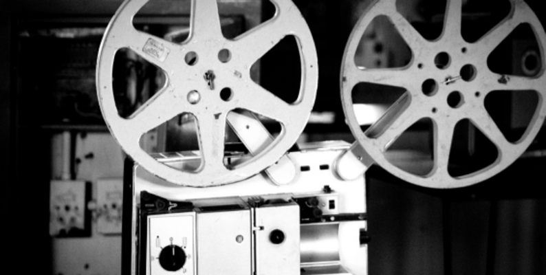

## **PARTIE1 : Facteurs affectant le box-office et leur corrélation.**

### Objectifs de l’Analyse

L’objectif de cette analyse est de comprendre les tendances et les facteurs clés influençant les performances financières des films, en utilisant des données variées sur les budgets de production, les recettes au box-office (nationales et mondiales), ainsi que les évaluations et approbations des spectateurs. Cette étude vise à identifier les relations entre ces variables pour offrir des perspectives aux studios de cinéma sur la manière de maximiser leurs profits tout en minimisant les pertes.

### QUESTION 1

> Définir les films qui ont fait des bénéfices et ceux qui ont perdu de l’argent

#### Visualisation：

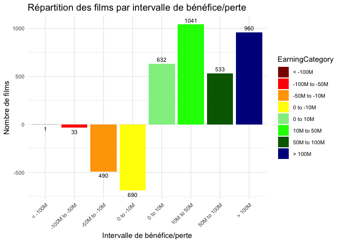

#### Conclusion：

En conclusion, le graphique montre que la majorité des films ont des bénéfices ou des pertes dans une plage de fluctuation relativement petite, avec peu de films réalisant des pertes ou des bénéfices très importants. Les performances financières des films sont principalement concentrées dans des intervalles de bénéfices modérés, en particulier dans les intervalles de 0 à 10 millions et de 10 à 50 millions. Les sociétés de production cinématographique doivent trouver un équilibre entre les films à petit budget et les films à gros budget pour maximiser les bénéfices et minimiser les pertes.

### QUESTION 2

> Analyser les distributions des recettes mondiales, des recettes domestiques et des budgets de production des films en utilisant un jeu de données spécifique.

#### Visualisation：

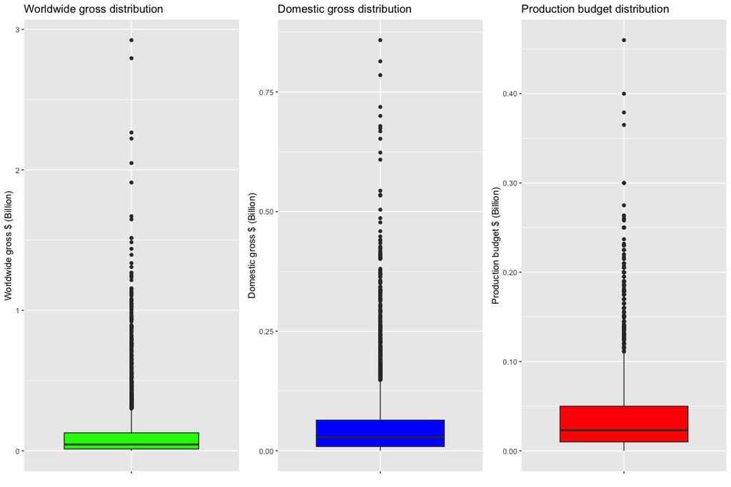

#### Analyse graphique:

Le graphique présente trois boîtes à moustaches (boxplots) illustrant la distribution des recettes mondiales, des recettes domestiques et des budgets de production des films. Les trois distributions sont représentées en milliards de dollars.

**Analyse globale**:

**Recettes domestiques (Domestic gross)** :

Les recettes domestiques sont généralement inférieures à 0,5 milliard de dollars pour la majorité des films. Comme pour les recettes mondiales, il y a des films exceptionnels qui dépassent 0,75 milliard de dollars.

**Budgets de production (Production budget)** :

La plupart des films ont un budget de production inférieur à 0,1 milliard de dollars. Cependant, il y a quelques films avec des budgets exceptionnellement élevés, atteignant jusqu’à 0,4 milliard de dollars.

**Analyse des points atypiques**:

**Recettes mondiales exceptionnelles** :

Les films qui génèrent plus de 2 milliards de dollars sont des anomalies significatives dans les données. Ces films sont probablement des blockbusters très populaires, souvent avec des franchises établies ou des réalisateurs renommés.

Exemples de tels films pourraient inclure des titres comme “Avatar” et “Avengers: Endgame”, qui ont attiré un public mondial massif.

**Recettes domestiques élevées** :

Les films avec des recettes domestiques dépassant 0,5 milliard de dollars sont également des cas atypiques. Ils bénéficient probablement d’une forte popularité nationale et de stratégies de marketing efficaces. Ces films peuvent aussi avoir des éléments culturels ou des stars nationales qui attirent un large public domestique.

**Budgets de production élevés** :

Les films avec des budgets de production supérieurs à 0,2 milliard de dollars sont souvent des films à gros budget avec des effets spéciaux lourds, des castings de stars ou des franchises établies.

Les films avec des budgets exceptionnels peuvent inclure des productions comme “Pirates des Caraïbes” ou “Star Wars”, qui nécessitent des investissements massifs pour la réalisation.

#### Conclusion:

**Distributions asymétriques** : Les trois distributions montrent une forte asymétrie à droite, indiquant que la majorité des films se situent dans une fourchette de recettes et de budgets relativement modestes, avec quelques exceptions notables qui tirent les moyennes vers le haut.

**Points atypiques significatifs** : Les films avec des recettes et des budgets exceptionnels sont rares mais ont un impact disproportionné sur les données globales. Ces films sont souvent des blockbusters avec une reconnaissance mondiale et des stratégies de marketing puissantes.

**Importance des franchises et des stars** : Les films qui se démarquent par leurs recettes et leurs budgets élevés sont souvent associés à des franchises établies, des réalisateurs renommés et des campagnes de marketing globales, soulignant l’importance de ces facteurs dans le succès financier des films.

En somme, bien que la majorité des films se situent dans une gamme de budgets et de recettes modérés, les exceptions notables illustrent l’impact significatif des blockbusters sur l’industrie cinématographique.

### QUESTION 3

> Existe-t-il une corrélation entre les recettes nationales et internationales, la durée du film, le budget du film, la note moyenne du film, le nombre de personnes ayant voté pour le film et l’indice d’approbation ?

#### Visualisation：

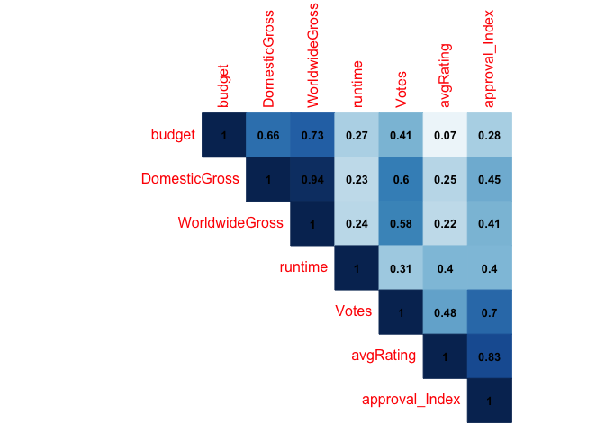

#### Analyse graphique：

Cette carte thermique montre la corrélation entre différentes variables dans un ensemble de données cinématographiques. Les corrélations vont de -1 (corrélation négative parfaite) à +1 (corrélation positive parfaite), une valeur proche de 0 indiquant qu’il n’y a pas de corrélation significative. Les couleurs plus foncées indiquent des corrélations plus fortes, le bleu représentant une corrélation positive et le rouge (s’il est présent) une corrélation négative. Le fait qu’aucune couleur rouge n’apparaisse ici signifie que la corrélation entre toutes les variables est positive.

1. Budget & WorldwideGross ; Budget & DomesticGross : Les coefficients de corrélation sont respectivement de 0,73 et 0,66, ce qui montre une forte corrélation positive. Cela signifie que plus le budget d’un film est élevé, plus ses recettes mondiales et nationales tendent à l’être.
2. DomesticGross & WorldwideGross : le coefficient de corrélation est de 0,94, ce qui indique une très forte corrélation positive entre les deux. Cela suggère que les films qui obtiennent habituellement de bons résultats au box-office national obtiendront également de bons résultats sur le marché mondial.
3. La note du film (avgRating) et l’indice d’approbation (approval_Index) : le coefficient de corrélation est de 0,83, ce qui indique qu’il existe une forte corrélation positive entre les deux mesures, ce qui signifie que les films ayant une note élevée ont tendance à avoir également un indice d’approbation élevé.
4. Les votes et l’indice d’approbation : le coefficient de corrélation est de 0,7, ce qui est une forte corrélation positive, indiquant que les films ayant plus de votes ont tendance à avoir un indice d’approbation plus élevé.
5. La corrélation relativement faible entre la durée du film et les autres variables suggère que la durée du film n’est pas un facteur majeur affectant le box-office, les notes et l’indice d’approbation.

#### Conclusion：

La forte corrélation positive entre le budget de production d’un film et les recettes du box-office mondial peut refléter le fait que les films à plus gros budget disposent de plus de ressources pour attirer le public, notamment grâce à des stars de renom, des effets spéciaux de haute qualité et un marketing intensif. La corrélation très élevée entre le box-office national et le box-office mondial peut signifier que les films à succès ont tendance à être généralement bien accueillis au niveau mondial, ou que les films ayant un box-office national élevé sont plus susceptibles de bénéficier d’une distribution et d’une publicité internationales. La note moyenne d’un film, le nombre de votes, est fortement corrélée avec l’indice d’approbation, car l’indice d’approbation est une valeur calculée à partir de la note moyenne du film et du nombre de votes combinés.

### Résumé général

En conclusion, les studios de cinéma doivent stratégiquement équilibrer leurs investissements entre les films à petit budget, qui constituent la majorité, et les blockbusters, qui bien que rares, peuvent générer des recettes massives et accroître la notoriété du studio.

## **PARTIE2 : Focus sur l’impact du genre sur le succès d’un film.**

### Objectifs de l’Analyse

Cette analyse vise à comprendre les préférences du public et la performance financière des différents genres cinématographiques. En examinant la répartition des parts de marché, les revenus moyens, la variabilité des performances et le retour sur investissement par genre, elle fournit des insights précieux pour les cinéastes, les distributeurs et les investisseurs.

#### Étapes du traitement des données pour les QUESTION1 et QUESTION2

1. Regroupement par Genre : Regrouper les données par la colonne Genre.
2. Calcul des agrégations : Pour chaque genre, calculer le nombre de films, la recette domestique moyenne et la recette mondiale moyenne.

### QUESTION 1

> Quel est le genre qui compte le plus grand nombre de films ?

#### Visualisation：

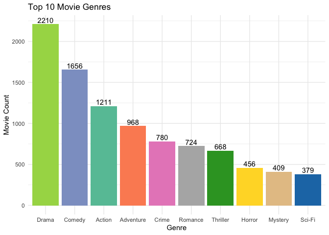

#### Analyse graphique:

1. **Le drame** est le genre de film le plus représenté avec 2210 films, occupant une position de premier plan.
2. **La comédie** arrive en deuxième position avec 1656 films.
3. **Les films d’action et d’aventure** sont respectivement en troisième et quatrième positions avec 1211 et 968 films.
4. **Les films de crime et de romance** ont des chiffres proches, avec 780 et 724 films respectivement.
5. **D’autres genres comme le thriller, l’horreur, le mystère et la** **science-fiction** ont des nombres relativement plus faibles avec respectivement 668, 456, 409 et 379 films.

#### Conclusion :

Ces données montrent que les drames et les comédies sont les genres les plus populaires, tandis que la science-fiction et le mystère sont moins représentés. Cela peut refléter les préférences des spectateurs et les tendances du marché.

### QUESTION 2

> Quels sont les types de films les plus performants au box-office ?

#### Visualisation:

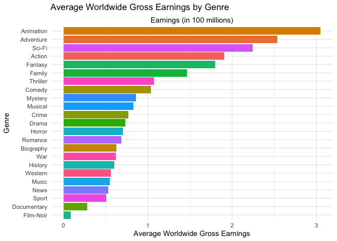

#### Disparités entre les recettes nationales et mondiales:

**Thriller**: Bien qu’important dans les recettes nationales, il occupe une position plus basse dans les recettes mondiales.

**Musical and Mystery**: Ces genres montrent une baisse notable de classement des recettes nationales aux recettes mondiales, ce qui pourrait indiquer une plus forte attraction nationale.

**Genres avec des classements cohérents**:

**Crime, Drama, Horror, et Biography**: Ces genres maintiennent des positions relativement cohérentes dans les recettes nationales et mondiales, suggérant une attraction équilibrée.

**War et Romance**: Montrent une légère baisse dans les recettes mondiales par rapport aux recettes nationales, mais restent néanmoins classés en milieu de tableau.

**Genres à faibles revenus**:

#### Conclusions:

1. **Animation, Adventure, et Sci-Fi** sont universellement populaires, montrant des recettes moyennes élevées tant au niveau national que mondial.
2. **Family et Comedy** ont une plus grande attraction nationale, indiquant des préférences culturelles qui pourraient ne pas se traduire aussi bien à l’international.
3. **Thriller, Musical, et Mystery** montrent une baisse notable d’attrait international, suggérant que ces genres pourraient être plus adaptés aux goûts nationaux.
4. **Les performers constants comme Crime, Drama, et Horror** montrent une attraction équilibrée sur différents marchés, ce qui en fait des genres fiables pour l’investissement.
5. **Les genres de niche comme Documentary, Film-Noir, et Western** ont un succès commercial limité, quel que soit le marché.

#### **La répartition du box-office mondial et nationale des films par genre**

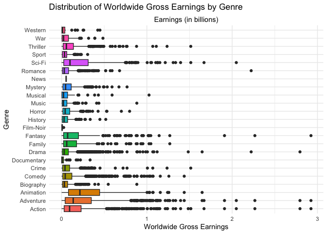

#### Analyse graphique:

**Animation et aventure en tête** : Les genres animation (Animation) et aventure (Adventure) ont les revenus moyens les plus élevés, montrant leur popularité et rentabilité. Genres à hauts revenus : Les genres science-fiction (Sci-Fi), action (Action) et fantasy (Fantasy) sont également performants, indiquant une préférence pour les films visuellement spectaculaires et imaginatifs.

**Genres à revenus faibles** : Les genres documentaire (Documentary), film noir (Film-Noir), journalisme (News) et western (Western) ont les revenus les plus bas, probablement en raison d’un public plus restreint et d’une attraction commerciale moindre.

**Variabilité des revenus** : La haute variabilité dans les genres aventure (Adventure), animation (Animation) et action (Action) montre que, bien que ces genres puissent produire des blockbusters, tous les films ne réussissent pas.

**Blockbusters** : Les valeurs aberrantes significatives dans les genres aventure (Adventure) et animation (Animation) indiquent que ces catégories peuvent produire des films à revenus exceptionnellement élevés.

#### Conclusions :

Les genres **d’animation et d’aventure** dominent en termes de revenus moyens, soulignant leur popularité et leur rentabilité. Les genres à hauts revenus comme **la science-fiction, l’action et la fantasy** bénéficient également d’une forte attractivité grâce à leurs éléments visuels spectaculaires. En revanche, les genres tels que **le documentaire, le film noir,** **le journalisme et le western** attirent un public plus restreint, se traduisant par des revenus plus faibles. Les genres **d’animation,** **d’aventure et d’action** sont les plus susceptibles de produire des blockbusters, bien que tous les films dans ces catégories ne réussissent pas de manière égale.

### QUESTION 3

> Quelle est la relation entre le nombre de films de différents genres, leur budget de production moyen et leurs recettes au box-office ?

#### Visualisation：

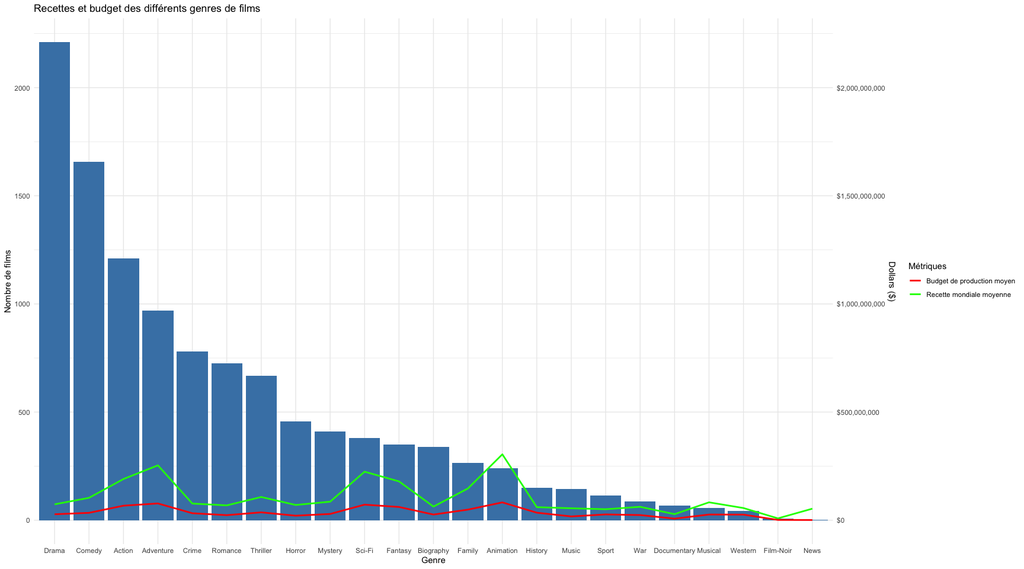

#### Conclusion：

Les performances commerciales des catégories de films ne sont pas nécessairement proportionnelles au nombre de productions. Si les catégories Drame, Comédie et Action sont celles qui comptent le plus grand nombre de productions, elles ne sont pas aussi performantes au box-office mondial et en termes de budgets de production que certaines des catégories plus petites telles que l’Aventure et l’Animation. Les catégories de films à fortes recettes telles que l’aventure et l’animation s’accompagnent généralement de budgets de production plus élevés, ce qui suggère qu’un investissement important peut conduire à des rendements élevés. Il peut être judicieux pour les studios d’explorer et d’investir dans des catégories plus petites mais très performantes, telles que les films d’aventure et d’animation, qui ont le potentiel de surpasser le box-office mondial !

### QUESTION 4

> Quelle est la relation entre la rentabilité des films dans différentes catégories et leurs notes moyennes ?

#### Visualisation：

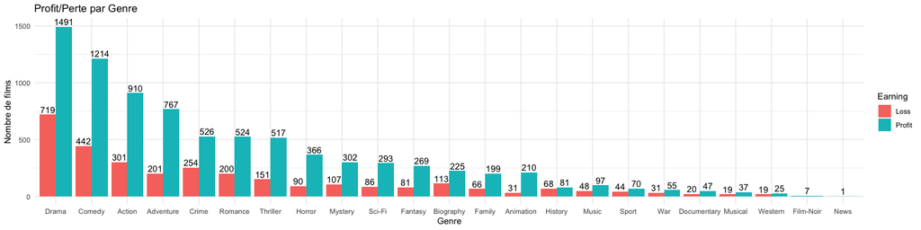

#### Analyse graphique：

1.**Distribution des Films par Genre** :

Drame : Le genre drame a le plus grand nombre de films avec 1491 films en profit et 719 films en perte, ce qui en fait le genre le plus représenté dans les deux catégories.

Comédie : La comédie suit avec 1214 films en profit et 442 films en perte, indiquant une forte présence dans le marché du film.

Action : Le genre action a 910 films en profit et 301 films en perte, montrant également une prédominance significative.

Aventure et Crime : Ces genres ont respectivement 767 films en profit et 201 films en perte pour l’aventure, et 526 films en profit et 254 films en perte pour le crime.

2.**Genres avec Moins de Représentation** :

Film noir et Actualités : Le film noir (7 en profit, 1 en perte) et les films d’actualités (1 en profit, 0 en perte) ont le moins de films représentés.

### QUESTION 5

> Analyser la relation entre le budget de production des films et leur acceptation par le public, tout en prenant en compte les genres principaux et le nombre de votes.

#### Visualisation:

Utiliser ggplot2 pour créer un diagramme de dispersion représentant la relation entre le budget de production et l’indice d’approbation. Les points sont colorés par genre et la taille des points reflète le nombre de votes.

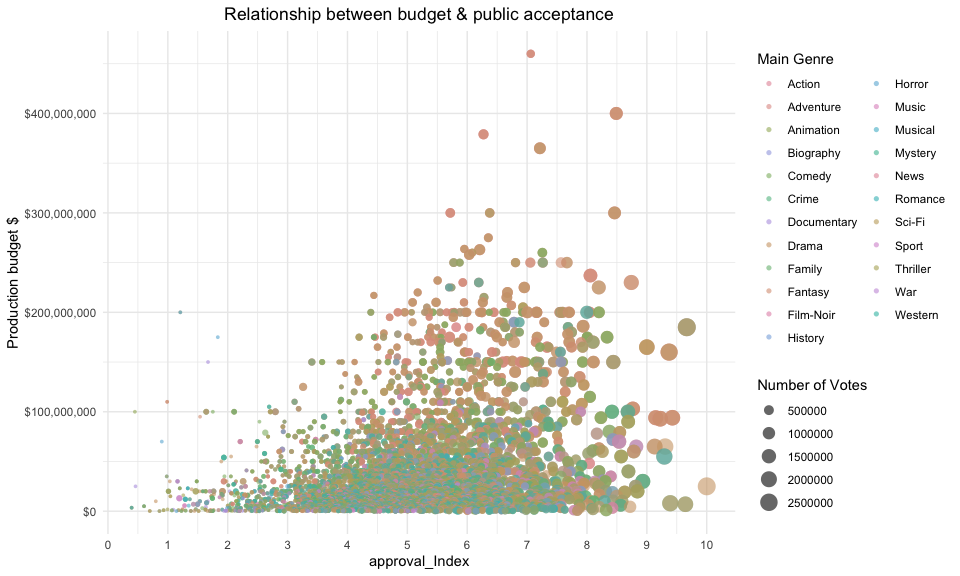

#### Analyse graphique:

Le graphique présente la relation entre le budget de production des films (en dollars) et leur indice d’approbation (approval_Index). Les points sur le graphique représentent différents films, colorés en fonction de leur genre principal et la taille des points indique le nombre de votes reçus.

**Analyse globale**:

**Tendance générale**:

La majorité des films avec un budget de production élevé (plus de 100 millions de dollars) ont un indice d’approbation relativement élevé, généralement supérieur à 5.

La plupart des films avec un budget de production faible (moins de 50 millions de dollars) ont une grande variation dans l’indice d’approbation, allant de 1 à 10.

**Concentration des points** :

Il y a une concentration notable de films avec un budget de production entre 0 et 50 millions de dollars et un indice d’approbation entre 3 et 6. Cela indique que de nombreux films à budget modeste obtiennent des niveaux d’approbation moyens.

Les films avec des budgets extrêmement élevés (plus de 200 millions de dollars) sont rares mais tendent à avoir des indices d’approbation variés.

**Analyse des points atypiques**:

**Films à haut budget et faible approbation**:

Certains films, malgré un budget de production très élevé (plus de 100 millions de dollars), ont un indice d’approbation inférieur à 5. Ces films peuvent avoir plusieurs raisons pour

**expliquer ce phénomène**:

Mauvais scénario ou réalisation, malgré des effets spéciaux et une production coûteuse.

Mauvaise réception critique ou public insatisfait.

Problèmes de distribution ou de marketing.

**Films à faible budget et forte approbation**:

D’autres films avec un budget de production faible (moins de 50 millions de dollars) obtiennent des indices d’approbation très élevés (supérieurs à 7).

**Ces succès peuvent être attribués à** :

Un scénario solide et une excellente réalisation.

Un bouche-à-oreille positif et une réception critique favorable.

Innovation ou originalité dans la présentation et le contenu.

#### Conclusion:

La relation entre le budget de production et l’acceptation du public montre une grande variabilité, influencée par le genre du film et le nombre de votes. Les films avec un budget élevé tendent à avoir une meilleure acceptation, mais il existe de nombreuses exceptions, indiquant que d’autres facteurs jouent un rôle important dans la popularité d’un film.

### QUESTION 6

> Quelles sont les catégories de films dont le retour sur investissement (ROI) moyen est le plus élevé ?

**La phase de préparation des données:**

1. **Conversion des données** : veillez à ce que tous les champs numériques, tels que le budget et les recettes des guichets, soient convertis en types numériques pour faciliter les calculs mathématiques.
2. **Décomposition des données**:

   **Chaîne divisée** : nous avons décomposé les multiples catégories du champ « type de film » en lignes séparées par « , », chaque ligne contenant un film et un genre, ce qui facilite l’analyse d’un seul genre.

   **Création d’une nouvelle variable** : nous avons créé une nouvelle variable, le retour sur investissement (ROI) : $\text{ROI} = \left( \frac{\text{Worldwide\_gross} - \text{Production\_budget}} {\text{Production\_budget}} \right) \times 100$
3. **Agrégation des données:**

   **Agrégation par catégorie:** nous avons agrégé les données par genre de film et calculé le retour sur investissement moyen pour chaque catégorie.

   **Tri:** les résultats ont été triés par retour sur investissement, montrant clairement les genres de films ayant le retour sur investissement le plus élevé, ce qui permet d’identifier rapidement les catégories les plus performantes.

#### Visualisation :

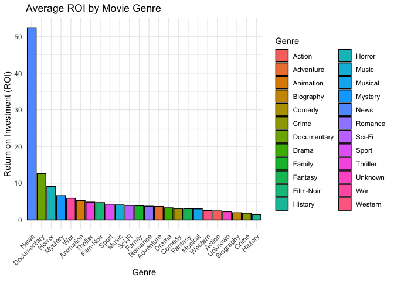

#### Analyse graphique:

Cet histogramme montre le retour sur investissement (ROI) moyen pour différents genres de films.

**Genres à ROI élevé :** Les actualités ont le retour sur investissement moyen le plus élevé de tous les genres, bien plus élevé que les autres genres. Cela pourrait indiquer que les films d’actualité sont moins chers à produire ou qu’ils ont un public restreint mais régulier. Les documentaires ont également un retour sur investissement relativement élevé, ce qui suggère que, comme pour les actualités, ces genres ont des coûts de production moins élevés ou une base d’audience fidèle qui assure leur rentabilité.

**Les genres à ROI moyen à élevé :** Les films de guerre, de suspense, les films noirs et les films d’horreur ont un retour sur investissement plus élevé. Ces genres peuvent également être en mesure de bien contrôler les coûts ou d’attirer fortement leur public cible, ce qui les rend relativement performants en termes de retour sur investissement.

**Les genres à ROI moyen :** Les genres tels que l’animation, la science-fiction, le thriller, la musique, le sport et la fantaisie affichent un retour sur investissement moyen, ce qui suggère que ces genres peuvent nécessiter un investissement plus important, mais qu’ils peuvent néanmoins obtenir de bons résultats sur le marché.

**Les genres à faible ROI :** Les genres populaires tels que le drame, la comédie, la romance et l’action ont un faible retour sur investissement. Il s’agit de genres populaires, mais le faible retour sur investissement peut être dû à des coûts de production plus élevés et à une concurrence intense sur le marché. Les biographies et l’histoire affichent également un faible retour sur investissement, ce qui peut refléter les coûts plus élevés ou les publics plus restreints qui peuvent être impliqués dans la représentation précise d’événements historiques ou biographiques.

#### Conclusion :

**Coût par rapport à la taille du public :** les genres ayant le meilleur retour sur investissement tendent à être ceux qui peuvent être produits à moindre coût ou ciblés sur des segments de public spécifiques qui garantissent une audience ou des ventes suffisantes par rapport à leur budget.

**Les genres populaires et le retour sur investissement :** les genres plus courants tels que l’action, la comédie et le drame ont généralement un retour sur investissement plus faible, peut-être en raison des coûts de production élevés et de la nécessité d’attirer un large public, ce qui peut s’avérer plus risqué en termes de rentabilité.

**Tendances du marché :** la popularité et la rentabilité des actualités et des documentaires peuvent refléter l’évolution actuelle du marché vers des divertissements plus basés sur les faits et la vie réelle, qui peut être influencée par les plateformes numériques et l’évolution des préférences du public.

Cette analyse des ROI par genre cinématographique offre aux investisseurs et producteurs de l’industrie cinématographique des insights précieux, leur permettant de prendre des décisions d’investissement plus éclairées, d’optimiser la répartition des budgets et de développer des stratégies de marketing plus efficaces. En comprenant quels genres de films peuvent générer un retour sur investissement plus élevé et ceux qui pourraient nécessiter des stratégies innovantes pour améliorer leur performance sur le marché, les professionnels du secteur peuvent mieux s’adapter aux dynamiques du marché et augmenter le potentiel de succès commercial de leurs projets.

### Résumé général

Les genres les plus produits, tels que le drame, la comédie et l’action, montrent des performances de marché relativement bonnes, mais comportent aussi des risques importants, notamment le drame, souvent déficitaire. Les genres aventure et animation, bien que moins produits, se révèlent très rentables avec des revenus exceptionnels, suggérant que des investissements élevés peuvent conduire à des rendements élevés. Cependant, les genres à faibles revenus, comme le documentaire et le film noir, attirent un public plus restreint et présentent une rentabilité commerciale moindre.

La popularité et la rentabilité varient significativement selon les genres. Les genres d’action, d’aventure et de science-fiction sont performants grâce à leur attrait visuel et leur capacité à produire des blockbusters. En revanche, les genres comme l’horreur et le mystère, bien que populaires, montrent une variabilité élevée dans leur performance financière, nécessitant une analyse de marché approfondie pour minimiser les risques.

En conclusion, pour maximiser le retour sur investissement, il est judicieux d’explorer et d’investir dans des genres performants tels que l’aventure et l’animation. Les genres courants, bien que populaires, peuvent présenter des risques en termes de rentabilité, et nécessitent des stratégies innovantes pour améliorer leur performance sur le marché. Les tendances actuelles montrent également une préférence pour des contenus plus réalistes et basés sur les faits, influencées par les plateformes numériques et l’évolution des préférences du public.

## **PARTIE3 : Focus sur l’influence du réalisateur sur le film.**

### Objectifs de l’Analyse

L’analyse des réalisateurs vise à évaluer la performance des cinéastes à travers trois paramètres clés : la note moyenne des films, les recettes moyennes et les budgets totaux de production. L’objectif est de distinguer les réalisateurs dont les films sont les mieux notés, ceux qui génèrent les recettes brutes les plus élevées, et ceux qui ont les budgets de production les plus importants. Cette évaluation nous permet de comprendre les différents styles et priorités des réalisateurs, qu’ils soient axés sur la qualité artistique ou sur le succès commercial.

### QUESTION 1

> Quels sont les réalisateurs les plus populaires auprès du public et les plus performants au box-office ?

#### Visualisation:

#### Les 10 premiers réalisateurs par note moyenne:

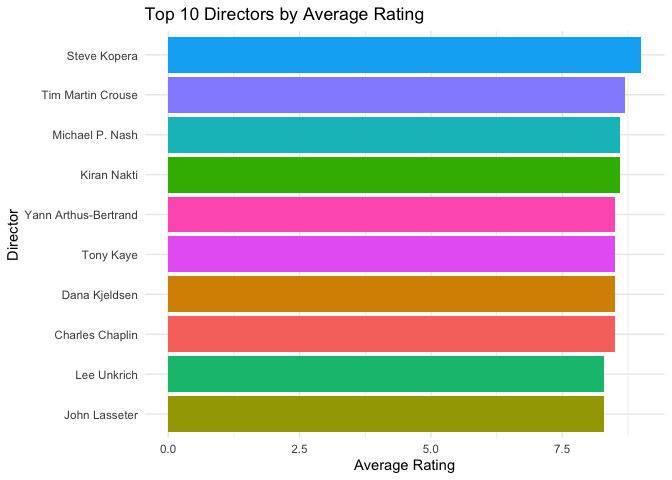

#### Top 10 des réalisateurs par revenus moyen:

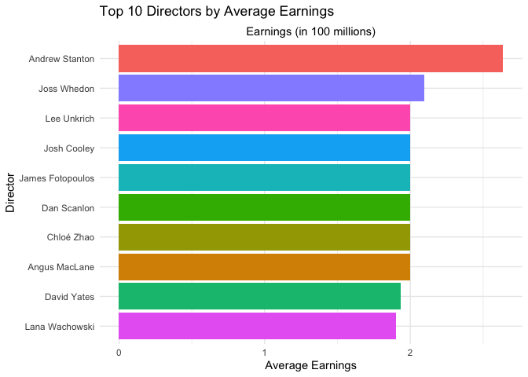

#### Analyse graphique:

Andrew Stanton est le premier réalisateur en termes de revenus moyens, avec une moyenne bien plus élevée que celle de tous les autres réalisateurs. Joss Whedon, Lee Unkrich et Josh Cooley ont également des moyennes élevées, chacun ayant gagné plus de 150 millions de dollars. Les recettes moyennes des 10 premiers réalisateurs sont toutes supérieures à 100 millions de dollars, ce qui indique que les films de ces réalisateurs se vendent très bien au box-office.

#### Conclusions :

**La différence entre les réalisateurs les mieux notés et les réalisateurs** **qui gagnent le plus** :

Réalisateurs bien notés : des réalisateurs comme Steve Kopera, Tim Martin Crouse et Michael P. Nash ont des films bien notés, mais cela ne signifie pas nécessairement que leurs films ont les recettes les plus élevées. Réalisateurs à fortes recettes : des réalisateurs comme Andrew Stanton, Joss Whedon et Lee Unkrich ont réalisé des recettes plus importantes, mais cela ne signifie pas nécessairement que leurs films sont les mieux notés.

**Facteurs influençant le succès d’un film** : Équilibre entre l’audience et les recettes : certains réalisateurs parviennent à trouver un équilibre entre une audience élevée et des recettes importantes, comme Joss Whedon et Lee Unkrich, qui non seulement obtiennent de bons résultats au box-office, mais ont également une audience relativement élevée pour leurs films. Domaines d’intérêt : certains réalisateurs se concentrent davantage sur la réalisation de films de grande qualité, acclamés par la critique, tandis que d’autres s’intéressent davantage au succès commercial et aux recettes au guichet.

### QUESTION 2

> Analyser les 10 réalisateurs ayant le plus dépensé en termes de budget de production de films.

#### Visualisation:

Utiliser ggplot2 pour créer un diagramme en barres horizontal représentant les 10 réalisateurs ayant le plus dépensé, avec une échelle de couleurs pour indiquer le montant total du budget.

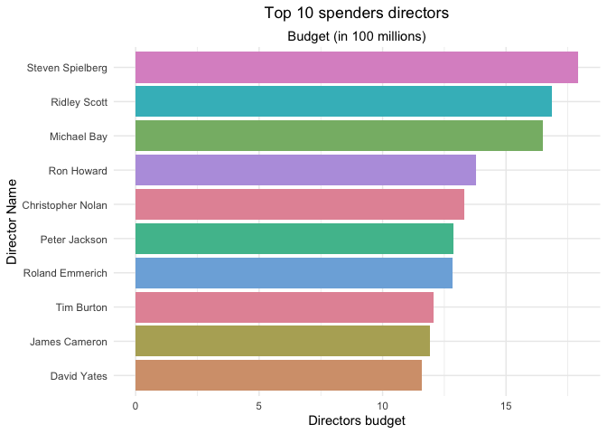

#### Analyse graphique:

Le graphique montre les dix réalisateurs ayant les budgets de production les plus élevés. Les noms des réalisateurs sont listés sur l’axe vertical, tandis que leurs budgets de production totaux sont représentés sur l’axe horizontal. Les couleurs différentes sont utilisées pour chaque réalisateur afin de les distinguer visuellement.

**Analyse globale**:

**Répartition des budgets** :

**Variation des budgets** :

Les écarts entre les budgets des réalisateurs montrent une hiérarchie nette, avec Spielberg en tête, suivi de Ridley Scott, Michael Bay, et ainsi de suite. Analyse des parties atypiques

**Steven Spielberg** :

Steven Spielberg a un budget de production total nettement plus élevé, ce qui indique soit une carrière prolifique avec de nombreux films à gros budget, soit plusieurs projets extrêmement coûteux.

Cela pourrait également refléter sa capacité à attirer des financements significatifs en raison de sa renommée et de son historique de succès au box-office.

**Répartition des autres réalisateurs** :

Les autres réalisateurs comme Ron Howard, Christopher Nolan, et Peter Jackson montrent des budgets élevés mais plus modérés, suggérant une gestion efficace de gros projets ou une production constante de films à succès.

#### Conclusion:

**Capacité de gestion de gros projets** : Les autres réalisateurs sur la liste démontrent également une capacité à gérer des projets à gros budget, bien que dans une moindre mesure par rapport à Spielberg.

**Diversité des réalisateurs** : La présence de réalisateurs de genres variés indique que la capacité à attirer et gérer de gros budgets n’est pas limitée à un genre spécifique mais s’étend à travers différentes catégories de films.

Les réalisateurs comme Spielberg et Cameron, connus pour leurs films à succès et à gros budget, montrent que la réputation et l’historique de succès jouent un rôle crucial dans l’obtention de gros financements pour leurs projets.

### Résumé général

Les conclusions de cette analyse montrent une distinction claire entre les réalisateurs les mieux notés et ceux qui réalisent les plus fortes recettes. Des réalisateurs comme Steve Kopera, Tim Martin Crouse et Michael P. Nash sont particulièrement bien notés, avec des films qui reçoivent des évaluations élevées, mais cela ne se traduit pas toujours par des recettes importantes au box-office. En revanche, des réalisateurs tels qu’Andrew Stanton, Joss Whedon et Lee Unkrich obtiennent des recettes importantes, bien que leurs films ne soient pas systématiquement les mieux notés.

Le succès d’un film peut être influencé par différents facteurs, notamment l’équilibre entre l’audience et les recettes. Certains réalisateurs parviennent à combiner une audience élevée et des recettes importantes, comme Joss Whedon et Lee Unkrich, qui réussissent à attirer un large public tout en générant des revenus considérables. D’autres réalisateurs se concentrent sur la qualité artistique et la reconnaissance critique plutôt que sur le succès commercial.

Enfin, les réalisateurs qui dépensent le plus en termes de budget de production, tels que Steven Spielberg, Ridley Scott et Michael Bay, sont associés à des blockbusters à gros budget. Ces données mettent en lumière les tendances de dépenses importantes qui accompagnent souvent les films à succès, soulignant l’importance des ressources financières dans la réalisation de productions cinématographiques de grande envergure.

## **PARTIE4 : Analyse de films de différentes époques.**

### Objectifs de l’Analyse

L’objectif de cette analyse est d’examiner l’évolution de l’industrie cinématographique en termes de genres prédominants et de tendances financières au fil des décennies. En analysant les graphiques et les données statistiques, nous cherchons à comprendre comment les genres de films ont changé au cours des différentes époques et comment les budgets de production et les recettes au guichet ont évolué.

### QUESTION 1

> Quelle est l’évolution du film à travers les différentes époques ?

#### Étapes du traitement des données:

Dans le cadre d’une étape supplémentaire d’ingénierie des fonctionnalités, nous créerons une nouvelle colonne qui regroupera les films en différentes époques sur la base de leurs dates de production.

> 1915 - 1928 : Silent Era

> 1928 - 1938 : The Talkies

> 1938 - 1954 : Golden Era

> 1954 - 1976 : The Change

> 1976 - 1999 : Dawn of Modern

> 1999 - 2023 : New Millenia

Cela nous permettra de mieux comprendre comment les tendances cinématographiques ont évolué au fil du temps.

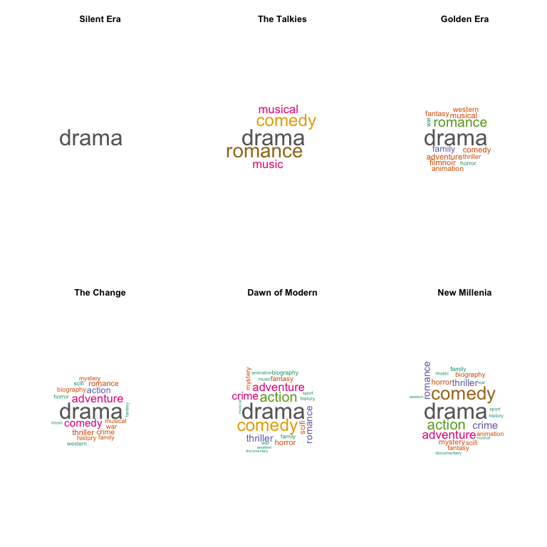

#### Analyse graphique：

1. **Silent Era** : Cette période est dominée par le genre “drame”. Étant donné que les films muets devaient transmettre des émotions sans dialogues, le drame, avec ses expressions visuelles intenses, était naturellement prédominant.
2. **The Talkies** : Avec l’avènement du son dans les films, de nouveaux genres comme le “romance”, “comédie”, et “musical” sont devenus populaires. Les réalisateurs ont commencé à explorer des histoires plus complexes et variées grâce à l’introduction du dialogue et de la musique.
3. **Golden Era** : Durant cette période, le “drame” reste central, mais on observe une diversification avec l’apparition significative de genres comme “roman”, “aventure”, et “comédie”. Cette époque voit l’essor de grands studios et de productions plus variées et riches en termes de genres.
4. **The Change** : L’ère du changement continue d’être dominée par le “drame” et la “comédie”, mais de nombreux nouveaux genres comme “action”, “mystery”, et “science-fiction” commencent à émerger. Les films deviennent plus innovants et variés, explorant de nouvelles technologies et narrations.
5. **Dawn of Modern** : À ce stade, les genres sont extrêmement diversifiés. Le “drame” reste important, mais on voit une forte présence de “thriller”, “action”, “romance”, et “fantasy”. Les films commencent à bénéficier de techniques de production modernes, incluant des effets spéciaux avancés.
6. **New Millenia** : Dans cette période contemporaine, les genres de films sont très variés avec une prédominance du “drame”, “comédie”, et “action”. Les films modernes explorent une multitude de thèmes et bénéficient des avancées technologiques pour offrir des expériences cinématographiques riches et immersives.

#### Conclusion

L’évolution du film montre une diversification croissante des genres au fil des époques. Du drame prédominant des films muets aux multiples genres des films contemporains, chaque période a élargi la palette cinématographique grâce aux avancées technologiques et aux changements socioculturels. Aujourd’hui, le cinéma offre une variété riche et immersive, explorant une multitude de thèmes et de genres.

#### Qulité et quantité à travers les époques

L’analyse de l’évolution des genres à travers les époques nous a fourni des informations précieuses sur l’évolution des tendances et des préférences de l’industrie cinématographique au fil du temps. Pour améliorer encore notre analyse, nous allons maintenant la compléter par des statistiques de base qui nous aideront à comprendre l’évolution de la qualité et de la quantité des films à chaque époque.

#### Nombre de films produits à chaque époque

Compression des colonnes de grande valeur, méthode pour équilibrer les histogrammes Maintient l’effet d’échelle logarithmique pour les valeurs élevées, mais effectue une transformation plus petite pour les valeurs plus faibles.

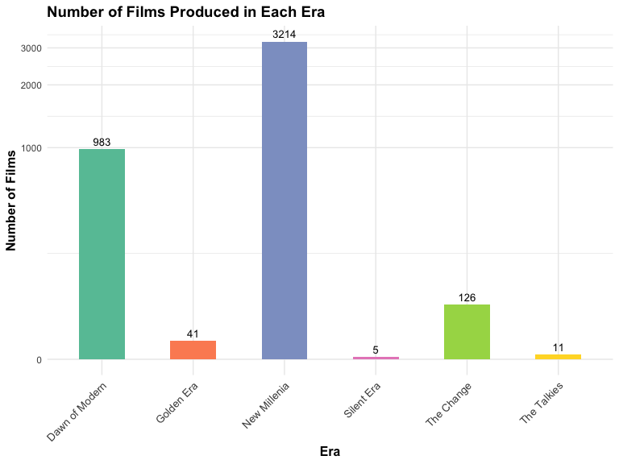

#### Comparaison des Average Rating entre les époques

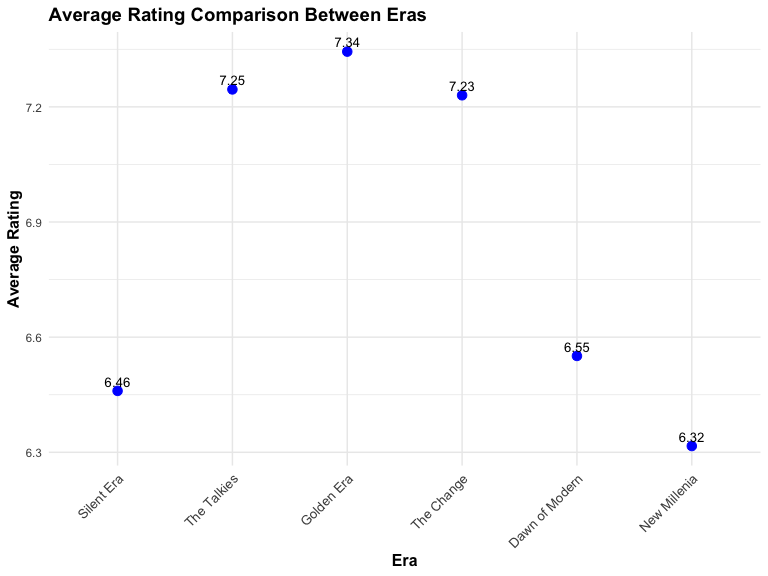

#### Average Domestic Gross et Worldwide Gross pour chaque époque

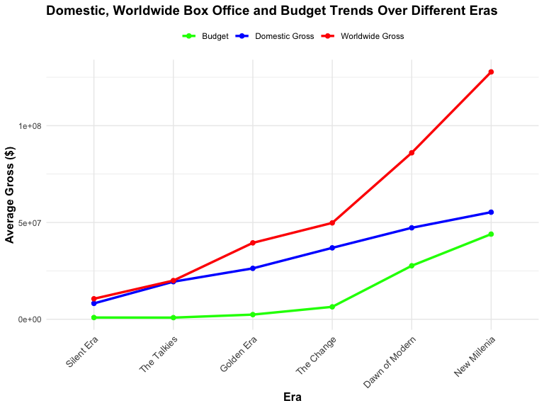

#### Analyse les graphiques et Conclusion：

D’un point de vue statistique, l’industrie cinématographique présente des tendances intéressantes.

**Tout d’abord**, l’augmentation du nombre de films et des recettes indique que l’ampleur de la production cinématographique s’est considérablement accrue au fil du temps.

**Cependant**, la qualité des films n’a pas suivi le rythme de l’augmentation de la production. Malgré l’augmentation du nombre de films, il n’a pas été possible de maintenir un niveau de qualité élevé et constant.

**Il convient de noter qu**’il y a eu un “âge d’or” dans l’histoire du cinéma, au cours duquel la qualité des films a atteint son apogée. Ces films étaient connus pour leurs intrigues remarquables, leurs performances mémorables et leur impact culturel durable.

**Toutefois**, au fil du temps, les progrès de la technologie cinématographique et l’innovation artistique ont pris du retard, ce qui fait que la qualité globale des films ne s’améliore pas de manière constante et connaît des fluctuations.

**Dans l’ensemble**, la recherche par l’industrie cinématographique d’un équilibre entre l’expansion de l’échelle et l’amélioration de la qualité n’a pas été un processus sans heurts, et il y a encore de la place pour des efforts continus.

### Résumé général

L’analyse révèle une diversification croissante des genres cinématographiques au fil des décennies, passant de la prédominance du drame durant l’ère des films muets à une variété de genres dans les films contemporains. Cette diversification a été influencée par les avancées technologiques et les changements socioculturels. Par ailleurs, les données financières montrent une tendance générale à la hausse des budgets de production et des recettes, avec une augmentation particulièrement notable des recettes mondiales depuis les années 1990. Cela souligne l’importance croissante des marchés internationaux pour l’industrie cinématographique. Malgré l’augmentation des coûts de production, les recettes ont globalement augmenté à un rythme plus rapide, indiquant une demande mondiale croissante pour le divertissement cinématographique. L’âge d’or du cinéma reste une période de référence pour la qualité des films, mais les films contemporains bénéficient des technologies modernes pour offrir des expériences riches et immersives.

## **PARTIE5 : Analyse des différents types de performances films dans différents pays.**

### Objectifs de l’Analyse

L’objectif de cette analyse est de comparer les préférences cinématographiques entre les marchés indiens et américains. En examinant les genres de films les plus populaires et les revenus moyens qu’ils génèrent, nous cherchons à identifier les similitudes et les différences dans les goûts des spectateurs de ces deux pays. Cette étude permet de mieux comprendre les tendances et les préférences culturelles, offrant ainsi des indications précieuses pour la production et la distribution de films.

### QUESTION 1

> Quels sont les genres de films les plus populaires sur les marchés cinématographiques respectifs des États-Unis et de l’Inde ?

#### Visualisation：

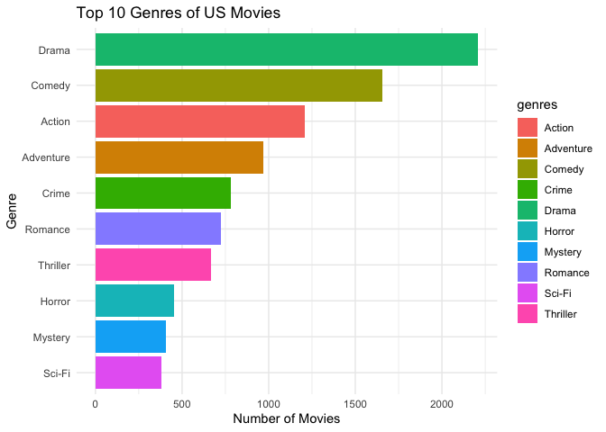

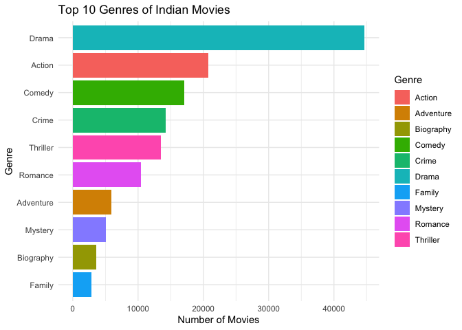

#### Analyse graphique

**Répartition des genres de films américains** :

La répartition des genres de films américains est assez équilibrée. Les genres les plus dominants sont le drame et la comédie, suivis par l’action, l’aventure et le crime.

Les films de science-fiction et de mystère sont relativement moins nombreux, mais ils figurent toujours parmi les dix premiers.

**Répartition des genres de films indiens** :

En Inde, les films de genre dramatique sont de loin les plus nombreux, avec un nombre de films deux fois supérieur à celui des autres genres.

Bien que les films biographiques soient moins nombreux, ils figurent parmi les dix premiers genres.

#### Conclusion :

**Points communs** :

Le drame et la comédie sont les genres de films les plus populaires dans les deux pays.

Les films d’action et de crime occupent une place importante dans les deux marchés.

**Différences** :

En Inde, les films biographiques sont dans le top 10, contrairement aux États-Unis.

**Préférences du marché** :

Le marché du film américain est plus diversifié, les spectateurs ayant une acceptation élevée pour différents types de films.

Le marché du film indien montre une préférence marquée pour les films dramatiques, d’action et de thriller, avec une place notable pour les films biographiques.

En résumé, ces graphiques reflètent les préférences cinématographiques des spectateurs de différents pays, fournissant ainsi des indications précieuses pour la production et la distribution de films.

### QUESTION 2

> Quel genre de film est le plus performant au box-office aux États-Unis et en Inde ?

#### Visualisation :

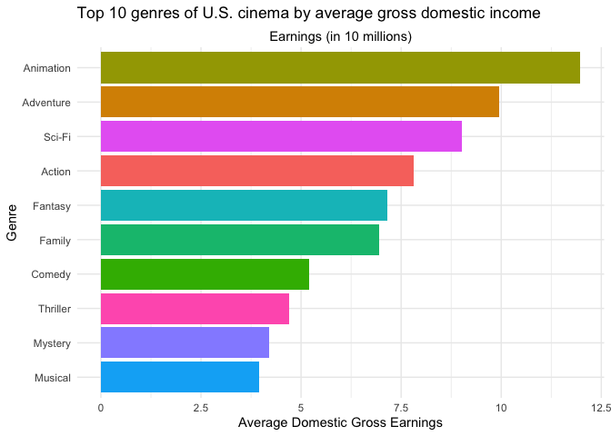

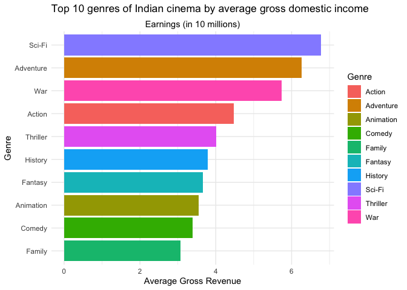

#### Analyse graphique

**Analyse des genres de films américains** :

Les comédies, thrillers, mystères et films musicaux ont des revenus moyens plus faibles, mais figurent toujours parmi les dix premiers.

**Analyse des genres de films indiens** :

Les films de fantaisie, d’animation, de comédie et de famille ont des revenus moyens plus faibles, mais figurent toujours parmi les dix premiers.

#### Conclusion :

**Points communs** :

Les films de science-fiction et d’aventure sont performants sur les marchés américain et indien, indiquant une popularité mondiale pour ces genres.

Les films d’action occupent une place importante sur les deux marchés, montrant leur attrait universel.

**Différences** :

Aux États-Unis, les films d’animation ont les revenus moyens les plus élevés, tandis qu’en Inde, ce sont les films de science-fiction.

Les films de guerre et d’histoire sont performants sur le marché indien, mais ne figurent pas parmi les dix premiers aux États-Unis.

Les films musicaux ont de bons résultats aux États-Unis, mais ne figurent pas parmi les dix premiers en Inde.

**Préférences du marché** :

Les spectateurs américains préfèrent les films d’animation, de famille et musicaux, qui ont généralement des coûts de production et des effets visuels élevés.

Les spectateurs indiens préfèrent les films de science-fiction, d’aventure et de guerre, qui peuvent mieux correspondre à leur contexte culturel et historique.

En somme, ces graphiques reflètent les préférences cinématographiques des spectateurs de différents pays, fournissant des indications précieuses pour la production et la distribution de films. Ces données peuvent aider les sociétés de production à mieux comprendre la demande du marché et à élaborer des stratégies de marché plus efficaces.

### QUESTION 3

> Quelles sont les différences entre les préférences des spectateurs américains et indiens en matière de genre cinématographique ?

#### Visualisation：

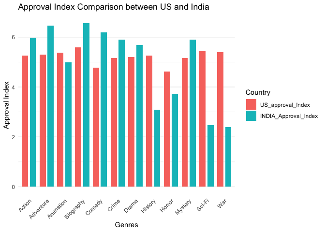

#### Analyse graphique:

**Genres avec un indice d’approbation plus élevé en Inde** :

Les genres Action, Adventure, Biography, Comedy, Crime, Drama, et Mystery sont plus appréciés en Inde. Cela peut indiquer une préférence pour les films narratifs et variés avec des éléments de comédie, de mystère, et des personnages forts.

**Genres avec un indice d’approbation plus élevé aux États-Unis** :

Les genres Animation, History, Horror, Sci-Fi, et War sont plus populaires aux États-Unis. Cela peut refléter une préférence pour les films visuellement impressionnants, historiques, effrayants et de science-fiction.

#### Conclusions :

**Inde** : Préfère les genres d’action, d’aventure, de biographie, de comédie, de crime, de drame, et de mystère, indiquant une appréciation pour une grande variété de récits et de styles narratifs.

**États-Unis** : Montre une préférence pour les films d’animation, historiques, d’horreur, de science-fiction et de guerre, ce qui peut refléter une attirance pour les récits visuellement captivants et thématiquement intenses.

Ces observations peuvent aider à comprendre les préférences culturelles dans les deux pays et à adapter les stratégies de production et de marketing pour répondre à ces goûts distincts.

## Shiny

La structure de cette brillante application est illustrée dans la figure suivante, où l’on peut voir que l’interaction est intitulée Films, et que la barre de composants sur la gauche se compose d’Informations (Générales, Détails), La liste, Les Directeurs, Box office, Les genres, Word Clouds, et la barre de composants contient également un menu déroulant Époque, qui permet à l’utilisateur de filtrer les données en sélectionnant une période de temps différente.

### Page 1: Informations sur le dataset

La première capture d’écran présente la page d’accueil de l’application Shiny, intitulée “Les films”. Sur cette page, on voit une section intitulée “Informations sur le dataset” qui affiche le nombre total de films dans le dataset, soit 4380 films. Cette vue fournit une vue d’ensemble rapide et générale de l’ampleur des données disponibles pour analyse.

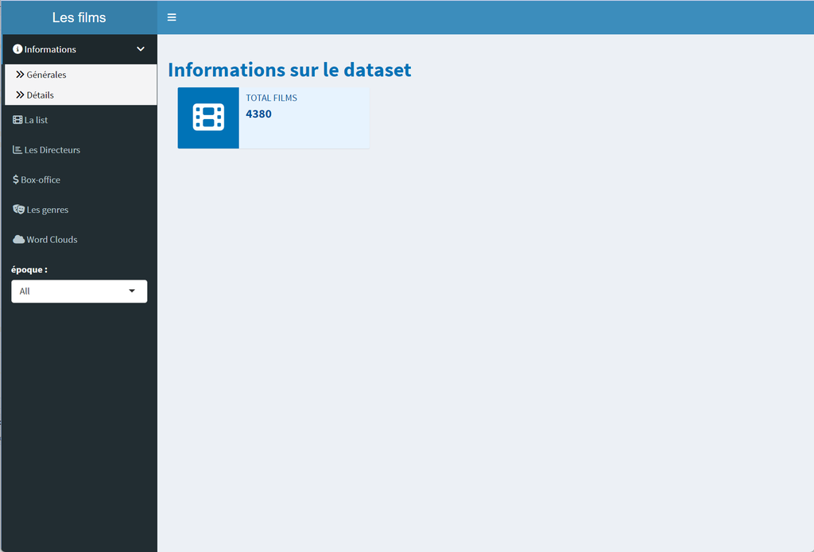

### Page 2: Informations détaillées sur le dataset

La deuxième capture d’écran montre la section “Informations détaillées sur le dataset” où l’utilisateur peut sélectionner un genre de film dans le menu déroulant. Les détails fournis incluent :Nombre total de films ,Durée moyenne ,Note moyenne ,Indice d’approbation moyen ,Recette moyenne domestique,Recette moyenne mondiale Ces informations permettent à l’utilisateur d’obtenir des détails spécifiques sur les films appartenant à un genre particulier.Et bien sûr, elle peut changer en fonction des choix de l’époque.

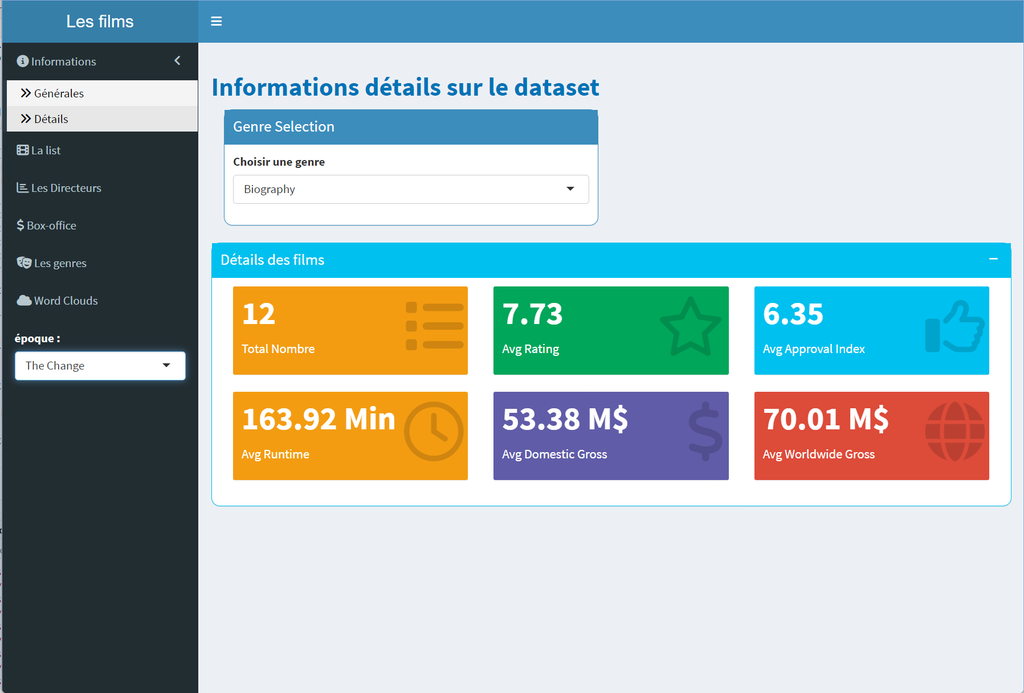

### Page 3: Liste des films

La troisième capture d’écran présente la section “Liste des films”, où une liste détaillée des films est affichée. Pour chaque film, les informations suivantes sont disponibles : Titre du film Date de production Genres Durée (en minutes) Nom du réalisateur Professions du réalisateur Année de naissance du réalisateur Année de décès du réalisateur Note moyenne du film Cette section permet à l’utilisateur de parcourir et de rechercher des films spécifiques dans la base de données.

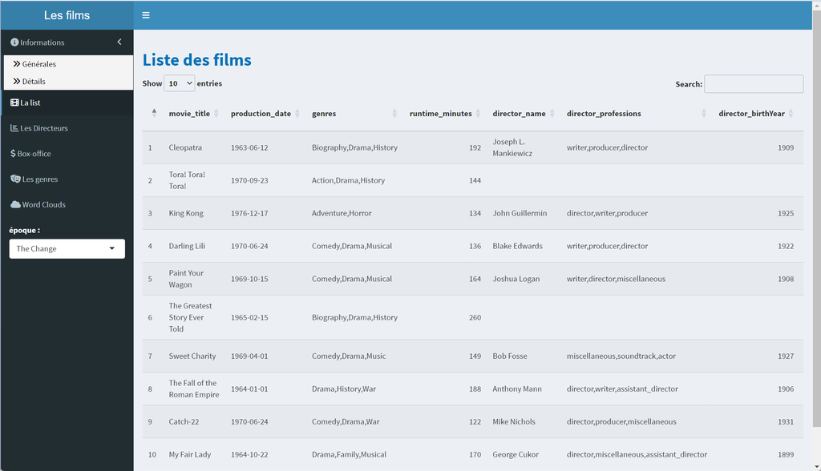

### Page 4: Classement des directeurs

La quatrième capture d’écran montre la section “Directeurs”, où les réalisateurs sont classés selon divers critères. Les graphiques affichés incluent :

Classement des réalisateurs par nombre de films Classement par recettes domestiques (en millions de dollars) Classement par recettes mondiales (en millions de dollars) Ces visualisations aident à identifier les réalisateurs les plus prolifiques et les plus rentables.

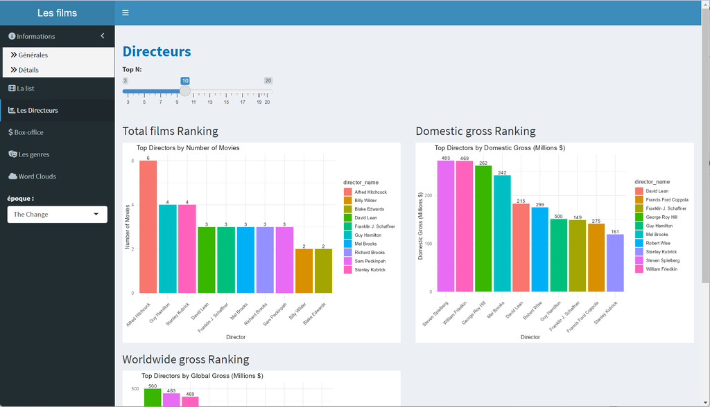

### Page 5: Impact sur le box-office

La cinquième capture d’écran présente la section “Impact sur le box-office”, avec des graphiques illustrant : Distribution des recettes mondiales Distribution des recettes nationales Distribution des budgets de production Relation entre le budget et l’acceptation publique Ces graphiques permettent de comprendre les tendances financières et les facteurs de succès des films.

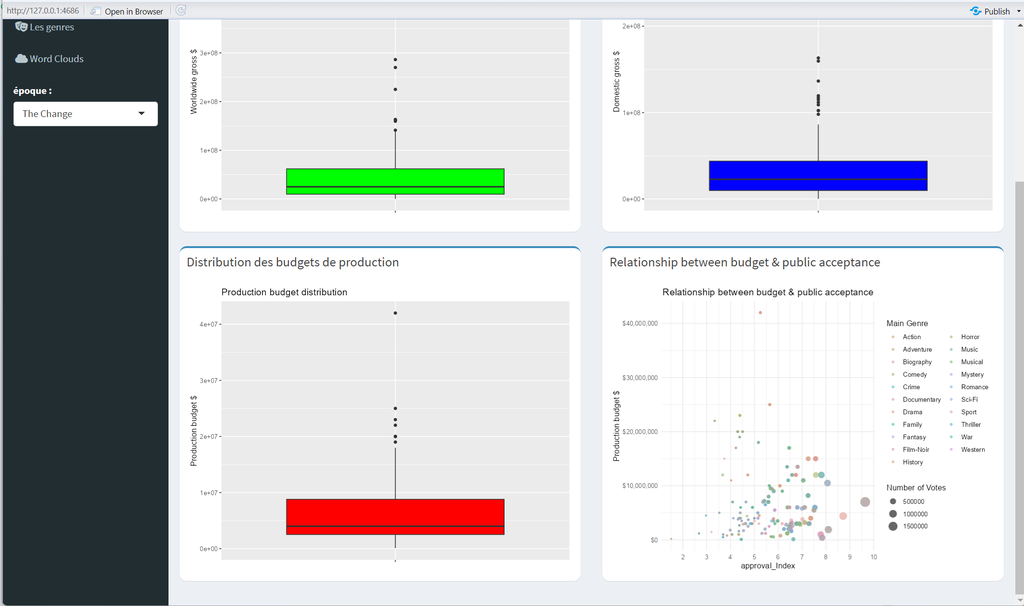

### Page 6: Comparaison entre les genres

La sixième capture d’écran montre la section “Comparaison entre les genres”, où divers graphiques comparent les genres de films. Les visualisations incluent : Les 10 principaux genres de films par nombre de films Distribution des recettes brutes nationales par genre Recettes brutes nationales moyennes par genre Ces comparaisons permettent d’analyser les performances et la popularité des différents genres de films.

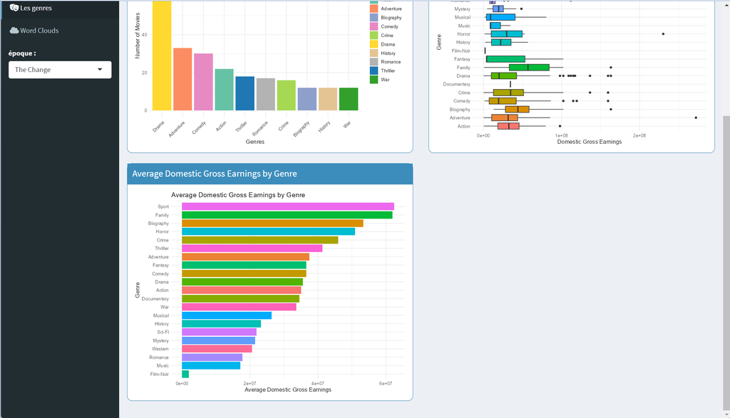

### Page 7: Word Clouds

Chaque page de l’application Shiny permet de filtrer les données par époque à l’aide du menu déroulant situé en bas à gauche. Les époques disponibles sont :

All Silent Era The Talkies The Change Golden Era Dawn of Modern New Millenia Cela permet d’effectuer des analyses plus fines et spécifiques selon les différentes périodes de l’histoire du cinéma.

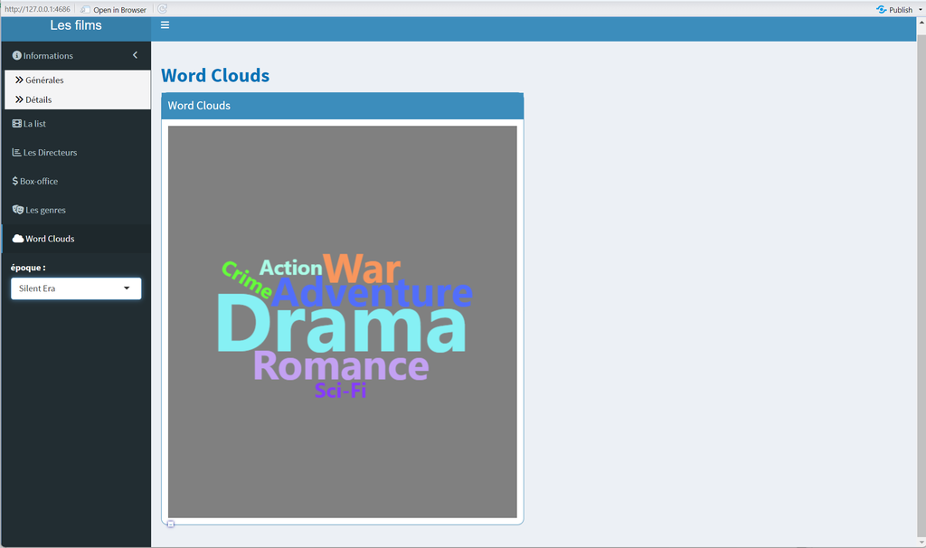

## **Conclusions**

Cet ensemble de données est très intéressant, notamment parce qu’il fournit une mine d’informations et de données sur divers aspects du cinéma (14 caractéristiques au total). Cela nous permet de mener des études multidimensionnelles sur les films, telles que l’analyse des genres, l’analyse des réalisateurs, l’analyse des époques, etc. Nous disposons ainsi d’une perspective plus complète, ce qui améliore la profondeur et l’étendue de la visualisation des données.

Parallèlement, nous avons ajouté un ensemble de données de films indiens à comparer aux films américains. Cela permet non seulement d’enrichir notre ensemble de données, mais aussi de fournir davantage de dimensions pour démontrer la diversité et la profondeur de la visualisation des données.

Dans le même temps, cela a également entraîné certains problèmes. Avec autant de facettes dans les données, la portée de nos questions de recherche est devenue trop large, ce qui a eu pour effet de rendre de nombreuses parties de l’étude plus superficielles, rendant difficile l’exploration et l’examen approfondi d’une section particulière.

Nous avons pensé qu’il serait préférable de définir d’abord la question de recherche, de la traduire en indicateurs nécessaires, puis de sélectionner l’ensemble de données requis sur la base de ces indicateurs. Cela réduit la portée du problème, mais les conclusions tirées seront plus ciblées. Il serait également possible d’inclure plusieurs autres ensembles de données nationales pour étudier le marché mondial du film.

> Dans ce cours, j’ai affiné les techniques de visualisation des données. Et j’ai appris beaucoup d’outils de visualisation. J’ai apprécié la manière d’enseigner de l’instructeur, qui a su stimuler ma réflexion. Si possible, j’espère réduire la partie théorique et apprendre davantage sur les parties qui peuvent être utilisées dans le travail pratique.

> — SHI Anhe

> Dans ce cours, j’ai pris conscience de l’importance de la visualisation des données et j’ai appris à choisir les bons graphiques, à les simplifier et à garantir l’exactitude et la lisibilité des données. J’ai également acquis de nombreuses compétences en matière de visualisation de données, telles que R, TABLEAU, etc. Tout cela m’a permis d’acquérir de solides compétences pour ma future carrière.

> — JIAO Zihang

> Je me suis rendu compte à quel point la visualisation de données peut être un point fort dans la compréhension des données et des phénomènes. “Une image vaut mille mots” prend ici tout son sens.

> — ZHANG Kaixuan

> Je suis très reconnaissante à mes professeurs pour leur enseignement attentif ; en tant qu’étudiante étrangère, je n’ai pas bien communiqué dans la langue, mais mes professeurs ont été patients et m’ont enseigné les connaissances, alors merci beaucoup ! En outre, je n’avais jamais eu l’occasion d’explorer des données dans une telle mesure (ou à une telle échelle) auparavant ; ce projet et ce cours m’ont permis d’acquérir de solides compétences pour ma future carrière.

> — ZHAO Biwei

## **Annexe**

**Membres de l’équipe et répartition des tâches**

**1. SHI Anhe**:

```
 Part1: Question 1,3
 Part2: Question 3,4
 présentation
```

**2. JIAO Zihang**:

```
 Part2: Question 1,2,6
 Part3: Question 1
 Part5
 présentation
```

**3. ZHAO Biwei**:

```
 Part1: Question 2
 Part2: Question 5
 Part3: Question 2
 Shiny Dashboard UI coding
 Shiny Dashboard Server coding
```

**4. ZHANG Kaixuan**:

```
 Part4
 Shiny Dashboard UI coding
 Shiny Dashboard Server coding
```